# Validation of soil carbon dynamics post land-use transition in a multisector dynamics model

October 12 2024

# 1 Methods

To begin the analysis, SOC data was taken from a basic run of GCAM, called a reference scenario. This models “business as usual” for the world, without any extra climate policies and assuming a certain level of overall warming. This GitHub repository contains all relevant data from this reference scenario used in our analysis, which was performed using R. Note that the SOC data, GCAM’s soil timescale list, as well as both the geopolitical regions list and the land use regions list are separate files, and must be merged before any additional steps can be performed. Below is the code used to load the data and libraries, as well as to merge the four files listed above. The final product is a data set where each SOC data point has an associated timescale value, land use region, and geopolitical region.

```r
library(dplyr)
library(ggplot2)
library(metafor)
library(tidyr)


#GCAM's SOC data
soilC <- read.csv(file = 'Data/GCAM_soilC.csv')

#GCAM's soil timescale list
read.csv(file = 'Data/soil_timescales.csv') %>%
  mutate(GCAM_region_ID = seq(1,32,by=1))-> timescales

#GCAM's land use region list
glus <- read.csv(file = 'Data/GLU_codes.csv')

#GCAM's geopolitical region list
regions <- read.csv('Data/GCAM_regions.csv')

#Merging the four above data sets
soilC %>%
  mutate(GLU_code = GLU) %>%
  right_join(glus, by='GLU_code') %>%
  right_join(regions, by='GCAM_region_ID') %>%
  right_join(timescales, by='GCAM_region_ID')-> soilC_regions
```

Much of the data contained within the SOC data set is irrelevant to this analysis, so it was removed.

```r
soilC_regions %>%
  select(Land_Type, soil_c, GLU_code, soilTimeScale, GCAM_region_ID, Basin_long_name) -> simple_soilC_regions
```

The experimental data compared to GCAM’s outputs was taken from Post & Kwon (2000) and Wei et al. (2014), both reviews of SOC measurements from the past 70 years. This data was manually digitized into a CSV file for analysis. This data did not explicitly list site locations for each measurement, so this information was determined from the paper referenced by the two studies. Once the location was determined, it was compared to GCAM’s 384 land use regions using the rmap tool and GCAM’s basin code mapping file. Then, the GLU code was manually added to the digitized data from Post & Kwon.

Once fully digitized, the experimental data was loaded into R as well. Note that there were several entries with missing timeframes or where the location of the sample could not be determined. These were assigned a value of ‘NA’.

```r
PostKwon <- read.csv(file= 'Data/Post and Kwon Data.csv', na.strings = c("", "NA"))
Wei <- read.csv(file= 'Data/Wei et al Data.csv', na.strings = c("", "NA"))
```

Once the experimental data was loaded in, each observation was mapped to is corresponding GCAM data point. This was done by simply adding the previously created GCAM data set to the experimental one by land use region, geopolitical region, and land use. This process was done twice–once for the initial land use and once for the final land use. This meant that, ultimately, each experimental data point had two associated GCAM SOC values–one for the initial land use, and one for the final land use.

This then allowed us to compute the GCAM SOC rate during land use change. This was done by simply subtracting the initial SOC value from the final value and dividing that by GCAMs soil timescale parameter. Finally, the k value (explained in depth in Wei et al.) was computed for both the experimental and GCAM data. The experimental and GCAM k values were computed using equations 1 and 2, respectively, below.
$$\begin{equation}
\tag{1}
k = -\frac{ln \left(\frac{C_f}{C_0}\right)}{t}
\end{equation}$$

$$\begin{equation}
\tag{2}
k = -\frac{ln (\frac{Rate \times t}{C_0} + 1)}{t}
\end{equation}$$

Experimental data from Wei et al. did not contain any raw rate information. Instead, the study only reported percent decrease in SOC concentration. This means we were only able to compare k values between the Wei et. al. data and GCAM. Additionally, k had to be computed with a modified equation, 3, below.

$$\begin{equation}
\tag{3}
k = -\frac{ln \left(1 - \frac{percent decrease}{100}\right)}{t}
\end{equation}$$

```
## [1] "Veldkamp (1994)" "Ulery (1995)"    "Beke (1990)"
```

```
## [1] 61
```

```
## [1] "White et al. (1976)"      "Pregitzer & Palik (1996)"
```

Note that, because of how the k value is computed for the experimental data, the sign was often mismatched. The sign of k corresponds to the opposite of the sign of the rate, which had to be corrected manually.

Once the experimental data was matched to its corresponding GCAM outputs, the two data sets (Post& Kwon and Wei et al.) were merged. Importantly, because the rate data does not exist for Wei et al., the rate data was not included in the aggregated data set.

```r
Full_Comparison <- bind_rows(
  select(PostKwon_Comparison, -Exp_Rate, -Rate_Difference),
  select(Wei_Comparison, -OC_decrease)
  )

#Now, we want to create another data frame that has all the repeated regions between the two studies
Full_Comparison %>%
  mutate(source_short = ifelse(source == 'Post & Kwon', 'PostKwon', 'Wei'),
         basin_source = paste(Basin_long_name, source_short)) %>%
  filter((paste(Basin_long_name, 'PostKwon') %in% basin_source) &
           (paste(Basin_long_name, 'Wei') %in% basin_source)) -> Duplicate_Comparison

counts = table(Duplicate_Comparison$basin_source)

Duplicate_Comparison %>%
  filter((counts[paste(Basin_long_name, 'Wei')] > 1) &
           (counts[paste(Basin_long_name, 'PostKwon')] > 1)) -> Duplicate_Comparison
```

```r
mean(Full_Comparison$Exp_k)
```

```
## [1] 0.03461801
```

```r
sd(Full_Comparison$Exp_k)
```

```
## [1] 0.07029091
```

```r
mean(Full_Comparison$GCAM_k)
```

```
## [1] 0.01274045
```

```r
sd(Full_Comparison$GCAM_k)
```

```
## [1] 0.01121584
```

```r
nrow(Full_Comparison)
```

```
## [1] 214
```

The results of the initial t-tests are below

```r
t.test(PostKwon_Comparison$Exp_k, PostKwon_Comparison$GCAM_k, alternative = 'two.sided')
```

```
##
##  Welch Two Sample t-test
##
## data:  PostKwon_Comparison$Exp_k and PostKwon_Comparison$GCAM_k
## t = -2.5879, df = 81.563, p-value = 0.01143
## alternative hypothesis: true difference in means is not equal to 0
## 95 percent confidence interval:
##  -0.009225734 -0.001206181
## sample estimates:
##     mean of x     mean of y
## -0.0054239070 -0.0002079495
```

```r
t.test(Wei_Comparison$Exp_k, Wei_Comparison$GCAM_k, alternative = 'two.sided')
```

```
##
##  Welch Two Sample t-test
##
## data:  Wei_Comparison$Exp_k and Wei_Comparison$GCAM_k
## t = 5.0457, df = 167.54, p-value = 1.167e-06
## alternative hypothesis: true difference in means is not equal to 0
## 95 percent confidence interval:
##  0.01834588 0.04192968
## sample estimates:
##  mean of x  mean of y
## 0.04682591 0.01668813
```

```r
t.test(Full_Comparison$Exp_k, Full_Comparison$GCAM_k, alternative = 'two.sided')
```

```
##
##  Welch Two Sample t-test
##
## data:  Full_Comparison$Exp_k and Full_Comparison$GCAM_k
## t = 4.4962, df = 223.84, p-value = 1.11e-05
## alternative hypothesis: true difference in means is not equal to 0
## 95 percent confidence interval:
##  0.01228898 0.03146614
## sample estimates:
##  mean of x  mean of y
## 0.03461801 0.01274045
```

Before the t-tests were performed, the data had to be put in long form and a transition type column was added:

```r
Full_Comparison %>%
  pivot_longer(cols = Exp_k:GCAM_k,
               names_to = "Type",
               values_to = "k") -> full_long_data

full_long_data %>%
  mutate(change = paste(Initial_Land_Use, Final_Land_Use, sep = '')) -> change_long_data
```

We also checked if the variances were equal.

```r
vars = var.test(k ~ Type, data = change_long_data)
```

Then, the skewness of the data was tested.

```
## [1] "Current Skewness: 6.22693192761866"
```

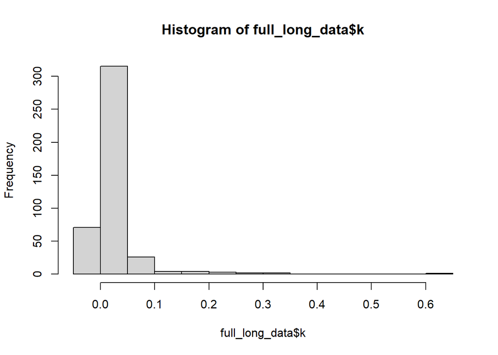

```
## [1] "Transformed Skewness: -3.00770673046884"
```

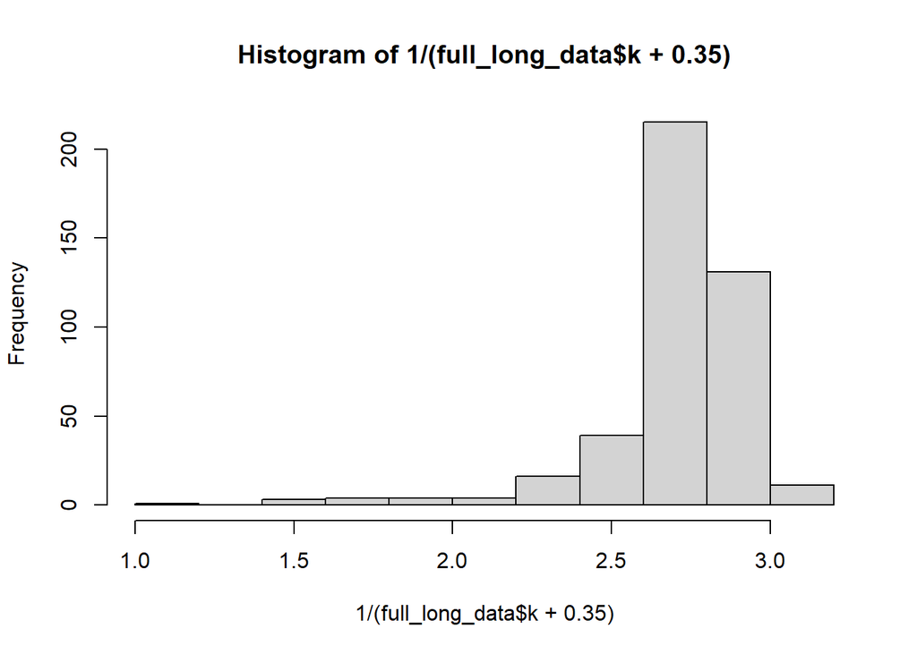

After improving the skew, we can perform analysis of variance on the data, but we run into issues with multicollinearity. Here we look for the effect of land-use transition type within the Post&Kwon comparison data (which has multiple LUC types) and the effect of geography within the Wei et al comparison data (which has many basins, but only one LUC type).

```r
library(car)
library(emmeans)
library(performance)

#Not possible to run model with both LUC and Basin,
#due to unequal distribution of data across
#LUC type and Basin

LUC_model <- lm(1/(k + 0.35) ~ Type * change,
               data = change_long_data[change_long_data$source == "Post & Kwon",])
Anova(LUC_model, type = "III")
```

```
## Anova Table (Type III tests)
##
## Response: 1/(k + 0.35)
##             Sum Sq Df   F value  Pr(>F)
## (Intercept) 58.457  1 9478.5419 < 2e-16 ***
## Type         0.003  1    0.4282 0.51469
## change       0.027  8    0.5373 0.82519
## Type:change  0.129  8    2.6146 0.01337 *
## Residuals    0.506 82
## ---
## Signif. codes:  0 '***' 0.001 '**' 0.01 '*' 0.05 '.' 0.1 ' ' 1
```

```r
LUC_emm <- emmeans(LUC_model, ~ Type|change, regrid = "response")
pairs(LUC_emm)
```

```
## change = CroplandForest:
##  contrast       estimate     SE df t.ratio p.value
##  Exp_k - GCAM_k  -0.0275 0.0420 82  -0.654  0.5147
##
## change = CroplandGrassland:
##  contrast       estimate     SE df t.ratio p.value
##  Exp_k - GCAM_k  -0.0114 0.0641 82  -0.178  0.8589
##
## change = CroplandPasture:
##  contrast       estimate     SE df t.ratio p.value
##  Exp_k - GCAM_k   0.0222 0.0297 82   0.748  0.4564
##
## change = ForestPasture:
##  contrast       estimate     SE df t.ratio p.value
##  Exp_k - GCAM_k   0.1173 0.0248 82   4.724  <.0001
##
## change = PastureForest:
##  contrast       estimate     SE df t.ratio p.value
##  Exp_k - GCAM_k  -0.1386 0.1111 82  -1.248  0.2155
##
## change = PastureShrubland:
##  contrast       estimate     SE df t.ratio p.value
##  Exp_k - GCAM_k   0.0602 0.0785 82   0.767  0.4455
##
## change = RockIceDesertGrassland:
##  contrast       estimate     SE df t.ratio p.value
##  Exp_k - GCAM_k   0.1201 0.1111 82   1.082  0.2825
##
## change = RockIceDesertShrubland:
##  contrast       estimate     SE df t.ratio p.value
##  Exp_k - GCAM_k  -0.1310 0.1111 82  -1.179  0.2416
##
## change = UrbanLandForest:
##  contrast       estimate     SE df t.ratio p.value
##  Exp_k - GCAM_k  -0.1254 0.1111 82  -1.129  0.2621
```

```r
performance::check_homogeneity(LUC_model, method = "auto")
```

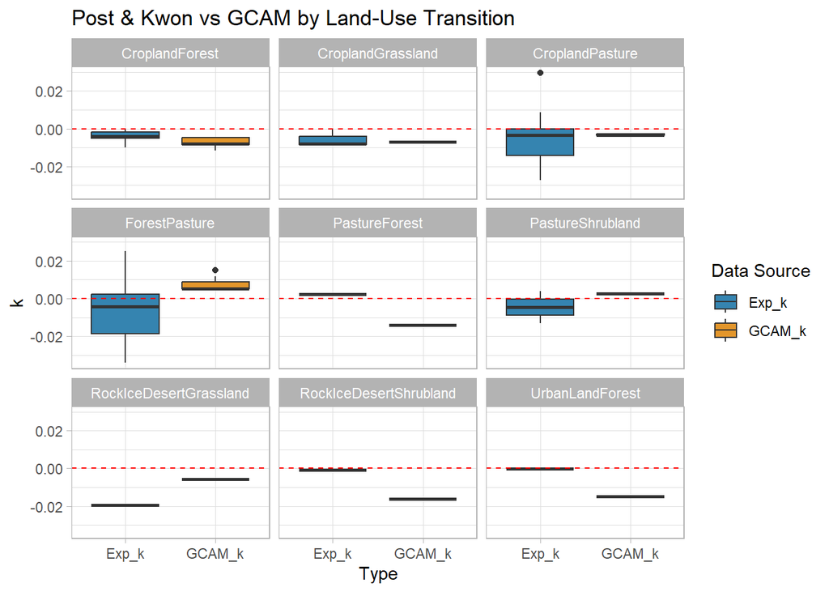

```r
ggplot(change_long_data[change_long_data$source == "Post & Kwon",], aes(Type, k, fill = Type)) + geom_boxplot() +
  scale_fill_manual(name = "Data Source",
                    values = c('Exp_k'='#3584B0',
                               'GCAM_k'='#e3962b')) +
  geom_hline(yintercept = 0, color = "red", linetype = 2) +
  ggtitle("Post & Kwon vs GCAM by Land-Use Transition") +
  facet_wrap(change ~.) + theme_light()
```

GCAM k values differ from Post & Kwon values specifically for Forest to Pasture transitions.

```r
Basin_model <- lm(1/(k + 0.35) ~ Type * Basin_long_name,
               data = change_long_data[change_long_data$source == "Wei et al",])
Anova(Basin_model, type = "III")
```

```
## Anova Table (Type III tests)
##
## Response: 1/(k + 0.35)
##                      Sum Sq  Df   F value    Pr(>F)
## (Intercept)          47.707   1 1227.7214 < 2.2e-16 ***
## Type                  0.042   1    1.0843 0.2988006
## Basin_long_name       7.166  44    4.1913 3.752e-13 ***
## Type:Basin_long_name  3.661  44    2.1411 0.0001535 ***
## Residuals             9.248 238
## ---
## Signif. codes:  0 '***' 0.001 '**' 0.01 '*' 0.05 '.' 0.1 ' ' 1
```

```r
Basin_emm <- emmeans(Basin_model, ~ Type|Basin_long_name, regrid = "response")
pairs(Basin_emm)
```

```
## Basin_long_name = Africa_East_Central_Coast:
##  contrast       estimate     SE  df t.ratio p.value
##  Exp_k - GCAM_k -0.10972 0.1054 238  -1.041  0.2988
##
## Basin_long_name = Amazon:
##  contrast       estimate     SE  df t.ratio p.value
##  Exp_k - GCAM_k -0.47224 0.1054 238  -4.482  <.0001
##
## Basin_long_name = Andaman_Nicobar_Islands:
##  contrast       estimate     SE  df t.ratio p.value
##  Exp_k - GCAM_k -0.02133 0.1610 238  -0.132  0.8947
##
## Basin_long_name = Bay_of_Bengal_North_East_Coast:
##  contrast       estimate     SE  df t.ratio p.value
##  Exp_k - GCAM_k -0.03085 0.2788 238  -0.111  0.9120
##
## Basin_long_name = Brahmani:
##  contrast       estimate     SE  df t.ratio p.value
##  Exp_k - GCAM_k -0.24981 0.0882 238  -2.834  0.0050
##
## Basin_long_name = Caribbean:
##  contrast       estimate     SE  df t.ratio p.value
##  Exp_k - GCAM_k -0.15010 0.1971 238  -0.761  0.4472
##
## Basin_long_name = Chao_Phraya:
##  contrast       estimate     SE  df t.ratio p.value
##  Exp_k - GCAM_k -0.04301 0.2788 238  -0.154  0.8775
##
## Basin_long_name = China_Coast:
##  contrast       estimate     SE  df t.ratio p.value
##  Exp_k - GCAM_k -0.06091 0.2788 238  -0.218  0.8272
##
## Basin_long_name = Dnieper:
##  contrast       estimate     SE  df t.ratio p.value
##  Exp_k - GCAM_k -0.02150 0.2788 238  -0.077  0.9386
##
## Basin_long_name = East_Brazil_South_Atlantic_Coast:
##  contrast       estimate     SE  df t.ratio p.value
##  Exp_k - GCAM_k -0.07761 0.1610 238  -0.482  0.6301
##
```

[output cut: 124 more lines]

```
## Basin_long_name = Sumatra:
##  contrast       estimate     SE  df t.ratio p.value
##  Exp_k - GCAM_k  0.06540 0.1247 238   0.525  0.6003
##
## Basin_long_name = Upper_Mississippi_Basin:
##  contrast       estimate     SE  df t.ratio p.value
##  Exp_k - GCAM_k  0.01748 0.0882 238   0.198  0.8430
##
## Basin_long_name = Uruguay_Brazil_South_Atlantic_Coast:
##  contrast       estimate     SE  df t.ratio p.value
##  Exp_k - GCAM_k -0.12816 0.2788 238  -0.460  0.6461
##
## Basin_long_name = Yucatan_Peninsula:
##  contrast       estimate     SE  df t.ratio p.value
##  Exp_k - GCAM_k -0.07381 0.1971 238  -0.374  0.7084
```

```r
performance::check_homogeneity(Basin_model, method = "auto")
```

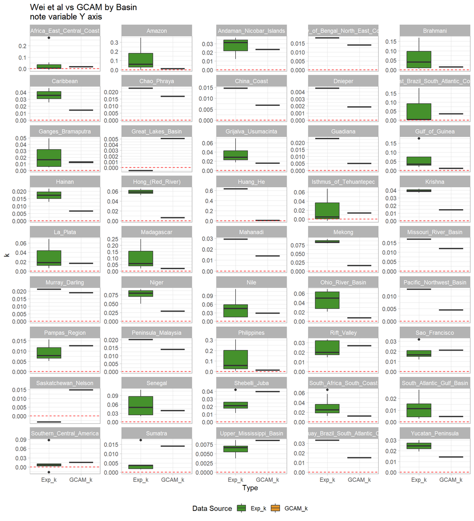

```r
ggplot(change_long_data[change_long_data$source == "Wei et al",], aes(Type, k, fill = Type)) + geom_boxplot() +
    scale_fill_manual(name = "Data Source",
                    values = c('Exp_k'='#45912c',
                               'GCAM_k'='#e3962b')) +
  geom_hline(yintercept = 0, color = "red", linetype = 2) +
  ggtitle("Wei et al vs GCAM by Basin\nnote variable Y axis") +
  facet_wrap(Basin_long_name ~., ncol = 5, scale = "free_y") + theme_light() +
  theme(legend.position = "bottom")
```

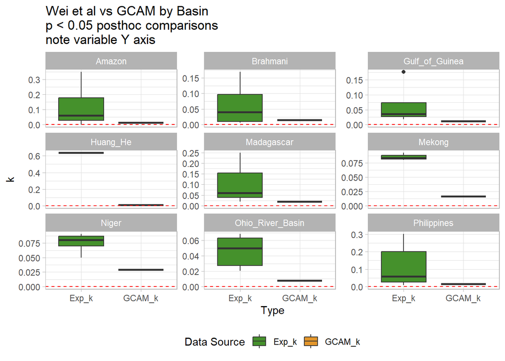

```r
change_long_data %>%
  filter(source == "Wei et al",
         Basin_long_name %in% c("Philippines",
                                "Ohio_River_Basin",
                                "Niger",
                                "Mekong",
                                "Madagascar",
                                "Huang_He",
                                "Brahmani",
                                "Gulf_of_Guinea",
                                "Amazon")) %>%
  ggplot(aes(Type, k, fill = Type)) + geom_boxplot() +
    scale_fill_manual(name = "Data Source",
                    values = c('Exp_k'='#45912c',
                               'GCAM_k'='#e3962b')) +
  geom_hline(yintercept = 0, color = "red", linetype = 2) +
  ggtitle("Wei et al vs GCAM by Basin \np < 0.05 posthoc comparisons \nnote variable Y axis") +
  facet_wrap(Basin_long_name ~., scale = "free_y") + theme_light() +
  theme(legend.position = "bottom")
```

```r
library(ARTool)

LUC_art_model <- art(1/(k + 0.35) ~ as.factor(Type) * as.factor(change),
               data = change_long_data[change_long_data$source == "Post & Kwon",])
LUC_art <- anova(LUC_art_model)
print(LUC_art)
```

```
## Analysis of Variance of Aligned Rank Transformed Data
##
## Table Type: Anova Table (Type III tests)
## Model: No Repeated Measures (lm)
## Response: art(1/(k + 0.35))
##
##                                     Df Df.res F value     Pr(>F)
## 1 as.factor(Type)                    1     82 10.8285  0.0014750  **
## 2 as.factor(change)                  8     82  3.8847  0.0006325 ***
## 3 as.factor(Type):as.factor(change)  8     82  5.7790 7.7159e-06 ***
## ---
## Signif. codes:   0 '***' 0.001 '**' 0.01 '*' 0.05 '.' 0.1 ' ' 1
```

```r
Basin_art_model <- lm(1/(k + 0.35) ~ as.factor(Type) * as.factor(Basin_long_name),
               data = change_long_data[change_long_data$source == "Wei et al",])
Basin_art <- anova(Basin_art_model)
print(Basin_art)
```

```
## Analysis of Variance Table
##
## Response: 1/(k + 0.35)
##                                             Df Sum Sq Mean Sq F value    Pr(>F)
## as.factor(Type)                              1 1.8743 1.87432 48.2350 3.581e-11
## as.factor(Basin_long_name)                  44 4.1932 0.09530  2.4525 8.511e-06
## as.factor(Type):as.factor(Basin_long_name)  44 3.6608 0.08320  2.1411 0.0001535
## Residuals                                  238 9.2482 0.03886
##
## as.factor(Type)                            ***
## as.factor(Basin_long_name)                 ***
## as.factor(Type):as.factor(Basin_long_name) ***
## Residuals
## ---
## Signif. codes:  0 '***' 0.001 '**' 0.01 '*' 0.05 '.' 0.1 ' ' 1
```

# 2 Results

Overall, GCAMs rate and k value outputs did not consistently match experimental values.

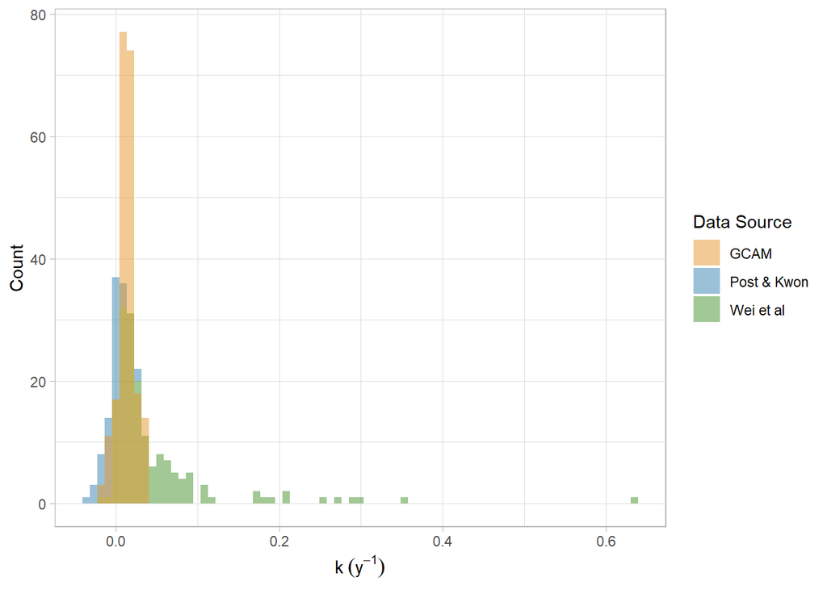

Figure 2.1: Histograms showing overlapping GCAM and experimental data for computed k values during land use change. Here, the experimental data is taken from both Post & Kwon and Wei et al.

```r
#Plot overlapping k histograms for the different k sources
ggplot() +
  geom_histogram(aes(x = Full_Comparison$Exp_k, fill = Full_Comparison$source), alpha = 0.5, bins = 75) +
  geom_histogram(aes(x = Full_Comparison$GCAM_k,  fill = 'GCAM'), alpha = 0.5, bins = 75) +
  xlab(expression(k~(y^-1))) + ylab('Count') +
  scale_fill_manual(name = "Data Source",
                    values = c('GCAM'='#e3962b', 'Wei et al' = '#45912c', 'Post & Kwon' = '#3584B0')) +
  theme_light()
```

```r
ggsave('all_k_histogram.jpeg', path = 'Graphs')
```

The average of the difference in means between k values was also plotted, grouped by transition type:

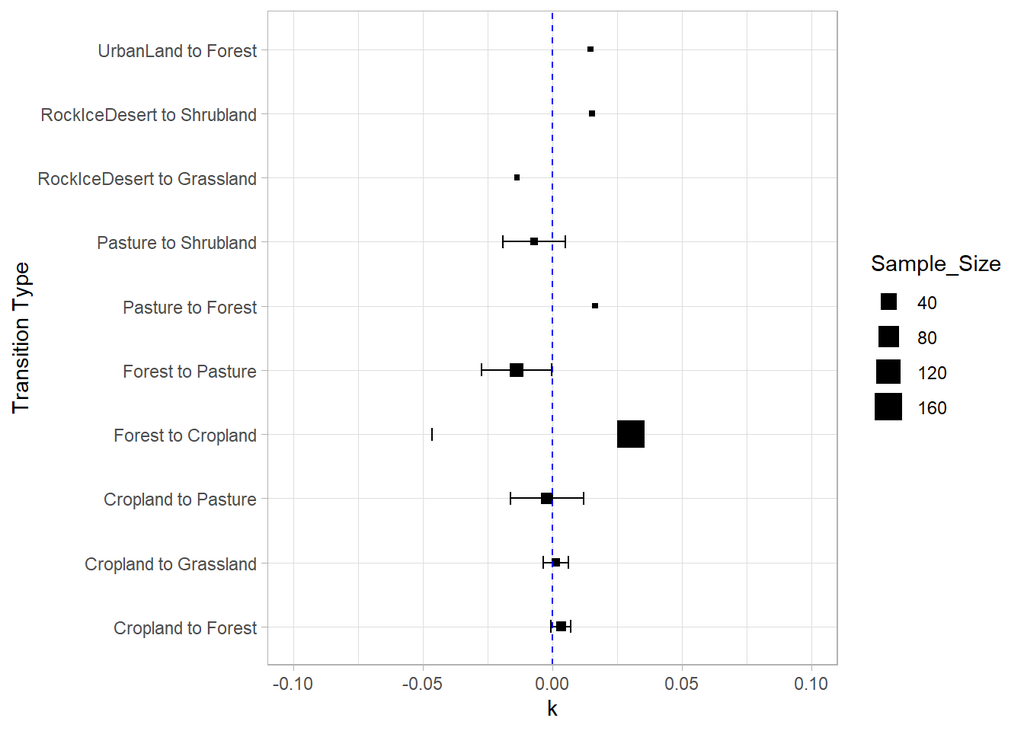

```r
#Make the mean graph
Full_Comparison %>%
  mutate(change = paste(Initial_Land_Use, Final_Land_Use, sep = ' to ')) %>%
  mutate(difference = Exp_k - GCAM_k) %>%
  group_by(change) %>%
  summarise(Mean_k = mean(difference), std_dev = sd(difference), Sample_Size = n()) -> mean_difference

ggplot(mean_difference, aes(x = Mean_k, y = change)) +
  geom_point(aes(size = Sample_Size), shape = 15) +
  labs(x = 'k', y = 'Transition Type') +
  geom_errorbar(aes(xmin=Mean_k - std_dev, xmax=Mean_k + std_dev), width=.2,
                position=position_dodge(0.05)) +
  xlim(-0.1, 0.1) +
  geom_vline(xintercept = 0, linetype = 'dashed', color = 'blue') +
  theme_light()
```

```r
ggsave('difference_plot.jpeg', path = 'Graphs')
```